# Презентация по лабораторной работе №12

Дисциплина: Архитектура компьютеров и операционные системы

Гусев Степан Андреевич

1032242444@rudn.ru

Российский университет дружбы народов

2026-04-07

# Информация

**Презентация по лабораторной работе №12**

**Автор:** Гусев Степан Андреевич

**Преподаватель:** Кулябов Дмитрий Сергеевич, д.ф.-м.н., профессор кафедры теории вероятностей и кибербезопасности

Российский университет дружбы народов

## Докладчик

- Гусев Степан Андреевич
- Студент программы “Бизнес-информатика”
- Российский университет дружбы народов им. П. Лумумбы
- 1032242444@rudn.ru
- https://github.com/stepagusev

## Цель

Изучить основы программирования в оболочке ОС UNIX/Linux. Научиться писать небольшие командные файлы.

## Задание

1. Написать скрипт, который при запуске будет делать резервную копию самого себя.
2. Написать пример командного файла, обрабатывающего любое произвольное число аргументов.
3. Написать командный файл — аналог команды ls.
4. Написать командный файл, который получает формат файла и вычисляет количество таких файлов.

# Выполнение лабораторной работы

## Скрипт 1

Создал файл 1.sh, дал права на выполнение, создал заранее директорию ~/backup, запустил скрипт и проверил, что появился архив.

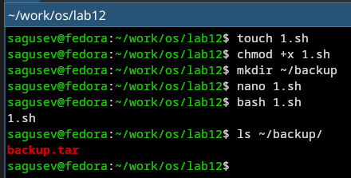

Рисунок 1: Создание скрипта 1

## Скрипт 1

Текст скрипта 1.

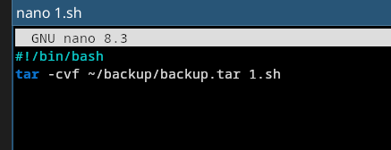

Рисунок 2: Скрипт 1

## Скрипт 2

Создал файл 2.sh, дал права на выполнение, запустил скрипт.

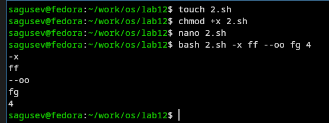

Рисунок 3: Создание скрипта 2

## Скрипт 2

Текст скрипта 2.

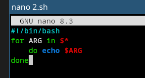

Рисунок 4: Скрипт 2

## Скрипт 3

Создал файл 3.sh, дал права на выполнение, запустил скрипт.

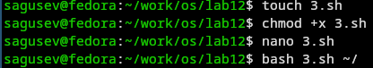

Рисунок 5: Создание скрипта 3

## Скрипт 3

Текст скрипта 3.

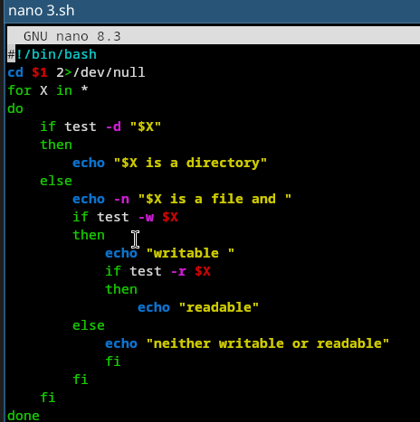

Рисунок 6: Скрипт 3

## Скрипт 3

Лог работы скрипта.

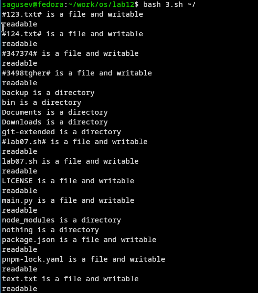

Рисунок 7: Лог скрипта 3

## Скрипт 4

Создал файл 4.sh, дал права на выполнение, открыл файл.

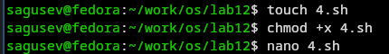

Рисунок 8: Создание скрипта 4

## Скрипт 4

Текст скрипта 4.

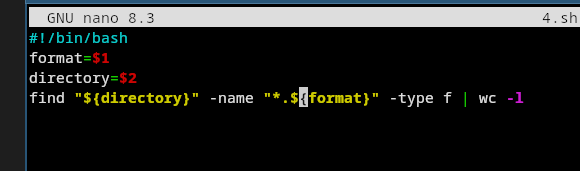

Рисунок 9: Скрипт 4

## Скрипт 4

Лог работы скрипта.

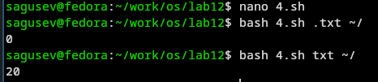

Рисунок 10: Лог скрипта 4

# Выводы

## Выводы

Я изучил основы программирования в оболочке ОС UNIX/Linux и научился писать небольшие командные файлы.